# Client Report - [Project 4: Can You Predict That?]

# The classification model achieves an accuracy of 90.8%, with higher precision and recall for homes built before 1980, indicating strong performance in identifying older homes with potential asbestos risks.Precision for Pre-1980 (Class 1): High precision (92%) means that when the model predicts a home is pre-1980, it is likely correct. Recall for Pre-1980: High recall (93%) means the model captures most homes built before 1980. This is critical for the client because identifying homes with potential asbestos risks is a priority.Reasoning: The high precision and recall for homes built before 1980 align with the client’s goal of identifying older homes potentially at risk of containing asbestos. The model slightly underperforms on homes built after 1980, which is acceptable as the focus is on pre-1980 homes.

# |Task 3

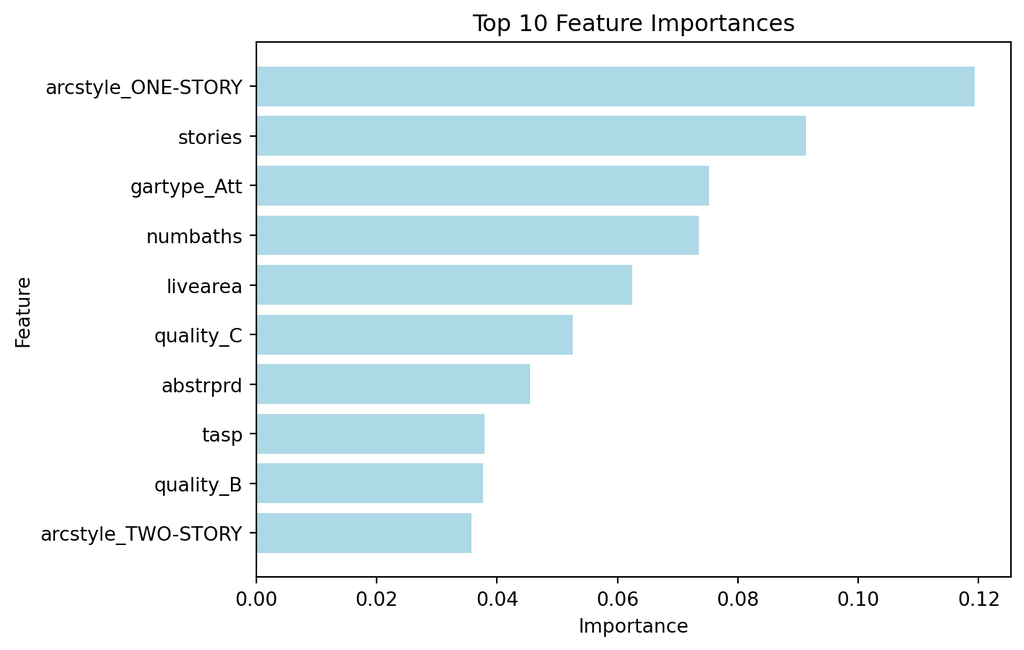

```python
import pandas as pd
import matplotlib.pyplot as plt
from sklearn.ensemble import RandomForestClassifier
from sklearn.model_selection import train_test_split

# Load the dataset
data = pd.read_csv('dwellings_ml.csv')

# Define features and target
X = data.drop(columns=['before1980', 'parcel', 'yrbuilt'])
y = data['before1980']

# Train model
X_train, X_test, y_train, y_test = train_test_split(X, y, test_size=0.2, random_state=42)
rf_model = RandomForestClassifier(random_state=42, n_estimators=100, max_depth=10)
rf_model.fit(X_train, y_train)

# Plot feature importance
importances = rf_model.feature_importances_
feature_names = X.columns
importance_df = pd.DataFrame({'Feature': feature_names, 'Importance': importances}).sort_values(by='Importance', ascending=False)

# Plot Top 10 Features
plt.barh(importance_df['Feature'][:10], importance_df['Importance'][:10], color='lightblue')
plt.title("Top 10 Feature Importances")
plt.xlabel("Importance")
plt.ylabel("Feature")
plt.gca().invert_yaxis()
plt.show()
```

# The feature importance chart highlights arcstyle_ONE-STORY and stories as the most influential factors in determining whether a house was built before 1980, followed by garage type (gartype_Att) and the number of bathrooms. Why Accuracy is Not Enough: While accuracy is high (90.8%), it does not account for class imbalances. In this dataset, there are more pre-1980 homes, making metrics like precision and recall critical to ensure the model performs well on both classes. Precision and Recall for Pre-1980 Homes: High precision and recall indicate the model is reliable for identifying older homes, addressing the client’s need to prioritize health and safety risks associated with asbestos.Reasoning: The combination of metrics demonstrates that the model is both accurate and effective at focusing on pre-1980 homes, which are the primary concern for the client. The confusion matrix reinforces this by showing that most misclassifications occur for post-1980 homes, which is less critical.

# Final Model Choice: The Random Forest model was selected for its ability to handle non-linear relationships and capture interactions between features. It achieved high accuracy without extensive parameter tuning.